# Estimación de la productividad de petróleo cuando el pasado se repite

Pablo Vidal

2024-02-14

# Introducción

Una serie temporal (time series) es una sucesión de datos ordenados cronológicamente y espaciados a intervalos iguales o desiguales. El proceso de forecasting consiste en predecir el valor futuro de una serie temporal, bien modelando la serie únicamente en función de su comportamiento pasado. Pero es posible realizar este forecast independiente de la variable tiempo?

En términos generales, al crear un modelo de forecasting se utilizan datos históricos con el objetivo de obtener una representación matemática capaz de predecir futuros valores. Esta idea se fundamenta sobre una asunción muy importante, el comportamiento futuro de un fenómeno se puede explicar a partir de su comportamiento pasado. Vease la siguiente definición:

*Forecast = patrones + varianzanoexplicada*

El primer término de la ecuación hace referencia a todo aquello que tiene un carácter repetitivo a lo largo del tiempo (tendencia, estacionalidad, factores cíclicos…). El segundo término, representa todo aquello que influye en la variable respuesta pero que no está recogido (explicado) por el pasado.

Cuanto mayor importancia tenga el primer término respecto al segundo, mayor será la probabilidad de exito al tratar de crear modelos de forecasting de tipo autoregresivo.

Realizar un buen estudio del fenómeno modelado y saber reconocer en qué medida su comportamiento puede explicarse gracias a su pasado, puede ahorrar muchos esfuerzos inecesarios.

En este documento se intenta predecir la producción acumulada de petróleo utlizando métodos de regresión lineal. Se hace uso de “tidyverse”, una sencilla librería de R que permite, entre otras cosas, múltiples gráficos para mostrar con claridad los resultados.

Pero que sucede cuando intentamos encontrar un patrón que no lo explica una regresión lineal? También se muestra con la ayuda gráfica de “boxplot” que variable influye en la productividad máxima de petróleo.

# Caso de uso

Vaca Muerta es una formación rocosa de la Patagonia Argentina que guarda es su estructura gas y petróleo de extracción no convencional. Los pozos para la explotación se crean mediante una fractura horizontal en profundidad con múltiples punzamientos espaciados para generar un efecto gran permeabilidad de la roca. Similar al efecto de la bombilla dentro de la yerba mate.

La página web http://datos.energia.gob.ar/ de la Secretaría de Energía de la Nación, guarda una gran cantidad de registros desde el 2006 sobre las fracturas y producción de petróleo y gas.

El creciente interes de inversores en la cuenca de Vaca Muerta soportado por el gran potencial energético para consumo interno y exportación, lo convierte en un fenómeno interesante de modelar.

# Tarea Empresarial

Hay maneras de estimar producciones de petróleo a tiempos efectivos establecidos para conocer anticipadamente el comportamiento del pozo? Existen variables que puedan influir en la performance del pozo?

# Preparando datos para la exploración

Utilizaremos la librería “tidyverse”

```r
library(tidyverse)
```

## Originalidad

Cada compañia exploradora de pertróleo y gas en la cuenca de Vaca Muerta registra sus datos de fractura y producción mensulamente en el servidor de la Secretaría de Energía de la Nación y son datos abiertos de uso público a travez de la dirección web http://datos.energia.gob.ar/. Son de primera fuente que representan el 100% de las perforaciones en la cuenca desde sus inicios y pueden descargarse en 2 archivos con formato CSV.

### df_frac:

El primer archivo .csv contiene datos de fracturas de pozos gas/petroleo que lo descargamos y transformamos en el dataframe “df_frac”.

```r
url_1 <-"http://datos.energia.gob.ar/dataset/71fa2e84-0316-4a1b-af68-7f35e41f58d7/resource/2280ad92-6ed3-403e-a095-50139863ab0d/download/datos-de-fractura-de-pozos-de-hidrocarburos-adjunto-iv-actualizacin-diaria.csv"
  df_frac <- read.csv(url_1)
```

### df_prod:

El segundo archivo .csv contiene datos de producción de pozos gas/petroleo que lo descargamos y transformamos en el dataframe “df_prod”.

```r
url_2 <- "http://datos.energia.gob.ar/dataset/c846e79c-026c-4040-897f-1ad3543b407c/resource/b5b58cdc-9e07-41f9-b392-fb9ec68b0725/download/produccin-de-pozos-de-gas-y-petrleo-no-convencional.csv"
df_prod <- read.csv(url_2)
```

## Metadatos

### df_frac

Vemos como se compone la estructura de df_frac que contiene 3649 observaciones y 30 variables.

```r
str(df_frac)
```

```
## 'data.frame':    3649 obs. of  30 variables:
##  $ id_base_fractura_adjiv      : int  30 31 37 38 39 40 41 42 43 44 ...
##  $ idpozo                      : int  159910 159910 159219 159220 159221 160426 160518 160519 160427 160330 ...
##  $ sigla                       : chr  "APS.Nq.ADC.xp-1033" "APS.Nq.ADC.xp-1033" "YPF.Nq.AdlA-1001(h)" "YPF.Nq.AdlA-1002(h)" ...
##  $ cuenca                      : chr  "NEUQUINA" "NEUQUINA" "NEUQUINA" "NEUQUINA" ...
##  $ areapermisoconcesion        : chr  "AGUA DEL CAJON" "AGUA DEL CAJON" "AGUADA DE LA ARENA" "AGUADA DE LA ARENA" ...
##  $ yacimiento                  : chr  "AGUA DEL CAJON" "AGUA DEL CAJON" "AGUADA DE LA ARENA" "AGUADA DE LA ARENA" ...
##  $ formacion_productiva        : chr  "los molles" "los molles" "vaca muerta" "vaca muerta" ...
##  $ tipo_reservorio             : chr  "NO CONVENCIONAL" "NO CONVENCIONAL" "NO CONVENCIONAL" "NO CONVENCIONAL" ...
##  $ subtipo_reservorio          : chr  "SHALE" "SHALE" "SHALE" "SHALE" ...
##  $ longitud_rama_horizontal_m  : num  0 0 1437 1518 1482 ...
##  $ cantidad_fracturas          : int  3 1 18 19 19 18 19 19 25 25 ...
##  $ tipo_terminacion            : chr  "Punzado" "Punzado" "Tapón disparo" "Tapón disparo" ...
##  $ arena_bombeada_nacional_tn  : num  0 0 3761 3904 3949 ...
##  $ arena_bombeada_importada_tn : num  0 0 537 558 570 ...
```

[output cut: 16 more lines]

### df_prod

Vemos como se compone la estructura de df_prod que contiene 283913 observaciones y 40 variables.

```r
str(df_prod)
```

```
## 'data.frame':    283913 obs. of  40 variables:
##  $ idempresa             : chr  "YSUR" "YSUR" "YSUR" "YSUR" ...
##  $ anio                  : int  2018 2015 2018 2017 2018 2015 2018 2017 2018 2015 ...
##  $ mes                   : int  1 1 1 1 1 1 1 1 1 1 ...
##  $ idpozo                : int  130159 130300 130158 134632 130023 130021 130022 130021 130021 130519 ...
##  $ prod_pet              : num  0 6.19 6.58 14.41 9.9 ...
##  $ prod_gas              : num  96.6 108.8 134.9 239.9 965.4 ...
##  $ prod_agua             : num  13.36 4.9 9.64 27.21 23.2 ...
##  $ iny_agua              : num  0 0 0 0 0 0 0 0 0 0 ...
##  $ iny_gas               : num  0 0 0 0 0 0 0 0 0 0 ...
##  $ iny_co2               : num  0 0 0 0 0 0 0 0 0 0 ...
##  $ iny_otro              : num  0 0 0 0 0 0 0 0 0 0 ...
##  $ tef                   : num  28 31 31 31 28.4 ...
##  $ vida_util             : num  NA NA NA NA NA NA NA NA NA NA ...
##  $ tipoextraccion        : chr  "Plunger Lift" "Plunger Lift" "Plunger Lift" "Surgencia Natural" ...
```

[output cut: 26 more lines]

## Preparación

### df_frac_prep

Hay variables cualitativas que son irrevelantes para el análisis y otras que se repiten en el dataframe “df_prod”. Quitaremos todas pero dejaremos solo “idpozo” para utilizar como clave primaria en posterior transformación.

```r
df_frac_prep <- df_frac %>%
select(-id_base_fractura_adjiv,-sigla,-cuenca,-empresa_informante,-areapermisoconcesion,-yacimiento,-formacion_productiva,-tipo_reservorio,-subtipo_reservorio,-tipo_terminacion,-co2_inyectado_m3,-presion_maxima_psi,-potencia_equipos_fractura_hp,-fecha_data,-anio_if,-mes_if,-anio_ff,-mes_ff,-anio_carga,-mes_carga,-mes,-anio,)
```

El dataframe “df_frac_prep” resultante contiene 3649 observaciones y 8 variables (columnas).

### df_prod_prep

Quitemos las variables irrelevantes para el análisis posterior

```r
df_prod_prep <- df_prod %>%
  select(-anio,-mes,-iny_agua,-iny_gas,-iny_co2,-iny_otro,-areapermisoconcesion,-cuenca,-vida_util,-tipoextraccion,-tipoestado,-observaciones,-fechaingreso,-rectificado,-habilitado,-idusuario,-formprod,-profundidad,-formacion,-idareapermisoconcesion,-idareayacimiento,-provincia,-coordenadax,-coordenaday,-tipo_de_recurso,-proyecto,-clasificacion,-subclasificacion,-sub_tipo_recurso,fecha_prod=fecha_data)
```

El dataframe “df_prod_prep” resultante contiene 283913 observaciones y 11 variables (columnas).

# Proceso de datos sucios a datos limpios

### df_frac_clean

Crearemos un dataframe con el nombre “df_frac_clean” y limpiaremos los pozos que no tienen registro de longitud de rama horizontal.

```r
df_frac_clean <- df_frac_prep %>%
  filter(longitud_rama_horizontal_m>0)
```

De la limpieza nos resulta un dataframe con 1688 observaciones y 8 variables (columnas), es decir que con nuestro proceso de limpieza hemos descartado un **54%** de los pozos.

### df_prod_clean

Crearemos un dataframe con el nombre “df_prod_clean”. Filtraremos los pozos horizontales señalados con una “h” que se encuentra luego del guion en la variable “sigla” y el análisis lo haremos sobre los pozos pertrolíferos que tienen menor error de medición en la boca de pozo. Entonces filtraremos las observaciones en la variable “tipopozo” que tienen la cadena de texto “Pet” y tambièn las variables “prod_gas” y “prod_agua”. Eliminaremos las observaciones mensuales que no tuvieron registro de producción de petróleo y luego agruparemos por pozo para quedarnos solo con los que tienen 3 o mas observaciones.

```r
df_prod_clean <- df_prod_prep %>%
  separate(sigla,into=c("first_sigla","last_sigla"),sep="-",remove = FALSE)%>%
  filter(grepl("h",last_sigla))%>%
  filter(grepl("Pet",tipopozo))%>%
  filter(prod_pet>0)%>%
  group_by(idpozo)%>%
  filter(n()>=3)%>%
ungroup()%>%
  select(-first_sigla,-last_sigla,-prod_gas,-prod_agua)

# a veces la el nombre de la columna "idempresa" tiene error desde la descarga entonces para resolverlo vamos a renombrar la columna 1 como "idempresa"

colnames(df_prod_clean)[1] <- c("idempresa")

# en columna "empresa" hay diferentes nombres que se refieren a la misma empresa. Vamos a corregirlo

df_prod_clean['empresa'][df_prod_clean['empresa'] == 'PAN AMERICAN ENERGY (SUCURSAL ARGENTINA) LLC'] <- 'PAN AMERICAN ENERGY SL'
df_prod_clean['empresa'][df_prod_clean['empresa'] == 'VISTA OIL & GAS ARGENTINA SAU'] <- 'VISTA ENERGY ARGENTINA SAU'
df_prod_clean['empresa'][df_prod_clean['empresa'] == 'Vista Oil & Gas Argentina SA'] <- 'VISTA ENERGY ARGENTINA SAU'
df_prod_clean['empresa'][df_prod_clean['empresa'] == 'WINTERSHALL DEA ARGENTINA S.A'] <- 'WINTERSHALL ENERGIA S.A.'
```

# Transformando y analizando datos

### df_frac_tran

Este dataframe sera resultado calcular nueva variables “espaciamiento” que será útil en posterio análisis, cambio de formato fecha “chr” a “date” y rendondeo de variables numéricas a 0 decimal.

```r
df_frac_tran <- df_frac_clean %>%
  mutate(espaciamiento=longitud_rama_horizontal_m/cantidad_fracturas,.after = cantidad_fracturas,across(c(longitud_rama_horizontal_m,cantidad_fracturas,arena_bombeada_nacional_tn,arena_bombeada_importada_tn,agua_inyectada_m3,espaciamiento),round,0))
df_frac_tran$fecha_fin_fractura <- ymd(df_frac_tran$fecha_fin_fractura)
df_frac_tran$fecha_inicio_fractura <- ymd(df_frac_tran$fecha_inicio_fractura)
df_frac_tran$idpozo <- as.character(df_frac_tran$idpozo)
```

### df_prod_tran

```r
df_prod_tran <- df_prod_clean%>%
  group_by(idpozo)%>%
  arrange(fecha_prod)%>%
  mutate(prod_pet_acum=cumsum(prod_pet),tef_acum=cumsum(tef),.after = tef, across(c(prod_pet,tef,prod_pet_acum,tef_acum),round,0))%>%

# vamos a crear dos nuevas columnas "last_idempresa" y "last_empresa" porque hay pozos que en su historia fueron varias empresas que participaron de la producción. Eligamos la última empresa.

  mutate(last_empresa=last(empresa),last_idempresa=last(idempresa))%>%
  select(idpozo,sigla,last_idempresa,last_empresa,areayacimiento,everything(),-idempresa,-empresa)%>%
  ungroup()%>%
  arrange(idpozo)

# cambiando formato
df_prod_tran$fecha_prod <- ymd(df_prod_tran$fecha_prod)
df_prod_tran$idpozo <- as.character(df_prod_tran$idpozo)

# Interpolando con función "approx". La función "approx" da como salida dos vectores "x" e "y" entonces colocando "$y", nos entregua solo el vector "y". Como necesitamos "yout" a 90, 180, 360 y 720, definimoos estos valores "xout" y este único valor resultante luego con la función "mutate" lo replica para cada observación del grupo.

df_prod_tran <- group_by(df_prod_tran,idpozo)%>%
  mutate(prod_pet_acum_90 = approx(x = tef_acum, y = prod_pet_acum, xout = 90)$y,prod_pet_acum_180 = approx(x = tef_acum, y = prod_pet_acum, xout = 180)$y,prod_pet_acum_360 = approx(x = tef_acum, y = prod_pet_acum, xout = 360)$y,prod_pet_acum_720 = approx(x = tef_acum, y = prod_pet_acum, xout = 720)$y)%>%
  mutate(across(where(is.numeric), round, 0))%>%
  ungroup()

# agrupando tendremos un nuevo dataframe de una observación por pozo

df_prod_tran <- group_by(df_prod_tran,idpozo,sigla,last_idempresa,last_empresa,areayacimiento,prod_pet_acum_90,prod_pet_acum_180,prod_pet_acum_360,prod_pet_acum_720)%>%
  summarise()
```

### df_frac_prod_tran

Para comparar correctamente debemos suponer que todos los pozos fueron realizados a la misma longitud horizontal. Entonces estandarizremos todas las producciones a 2500 mt de longitd horizontal. Uniremos primero los dataframes “df_frac_tran” y “df_prod_tran” para luego dividir las producciones por su longitud horizontal multiplicada por 2500.

```r
df_frac_prod_tran <- inner_join(df_frac_tran,df_prod_tran,by="idpozo")%>%
  select(idpozo,sigla,last_idempresa,last_empresa,areayacimiento,everything())%>%
  arrange(idpozo)%>%
  mutate(longitud_rama_horizontal_m_N=longitud_rama_horizontal_m/longitud_rama_horizontal_m*2500,cantidad_fracturas_N=cantidad_fracturas/longitud_rama_horizontal_m*2500,arena_bombeada_nacional_tn_N=arena_bombeada_nacional_tn/longitud_rama_horizontal_m*2500,arena_bombeada_importada_tn_N=arena_bombeada_importada_tn/longitud_rama_horizontal_m*2500,agua_inyectada_m3_N=agua_inyectada_m3/longitud_rama_horizontal_m*2500,prod_pet_acum_90_N=prod_pet_acum_90/longitud_rama_horizontal_m*2500,prod_pet_acum_180_N=prod_pet_acum_180/longitud_rama_horizontal_m*2500,prod_pet_acum_360_N=prod_pet_acum_360/longitud_rama_horizontal_m*2500,prod_pet_acum_720_N=prod_pet_acum_720/longitud_rama_horizontal_m*2500,.keep = "unused")%>%
  mutate(across(where(is.numeric), round, 0))

# Mostremos la tabla lograda:

rmarkdown::paged_table(df_frac_prod_tran)
```

| idpozo | sigla | last_idempresa | last_empresa | areayacimiento | espaciamiento | fecha_inicio_fractura | fecha_fin_fractura | longitud_rama_horizontal_m_N | cantidad_fracturas_N | arena_bombeada_nacional_tn_N | arena_bombeada_importada_tn_N | agua_inyectada_m3_N | prod_pet_acum_90_N | prod_pet_acum_180_N | prod_pet_acum_360_N | prod_pet_acum_720_N |
| --- | --- | --- | --- | --- | --- | --- | --- | --- | --- | --- | --- | --- | --- | --- | --- | --- |
| 137008 | YPF.Nq.SOil.x-2h | YPF | YPF S.A. | LOMA CAMPANA | 93 | 2011-12-13 | 2011-12-30 | 2500 | 27 | 859 | 5104 | 46724 | 10401 | 20578 | 32454 | 50918 |
| 137240 | YPF.Nq.LLL.a-514h | YPF | YPF S.A. | LOMA CAMPANA-LLL | 89 | 2012-01-20 | 2012-01-31 | 2500 | 28 | 168 | 6145 | 45825 | 4029 | 6956 | 11299 | 18990 |
| 137390 | YPF.Nq.LLL-523(h) | YPF | YPF S.A. | LOMA CAMPANA-LLL | 90 | 2012-02-04 | 2012-02-17 | 2500 | 28 | 755 | 5388 | 39656 | 4204 | 8393 | 13080 | 18060 |
| 137609 | YPF.Nq.LLL-534(h) | YPF | YPF S.A. | LOMA CAMPANA-LLL | 75 | 2012-05-13 | 2012-05-26 | 2500 | 34 | 750 | 6021 | 43012 | 4204 | 7027 | 11357 | 14454 |
| 137680 | MED.Nq.ACh.x-1026 (h) | PES | PATAGONIA ENERGY S.A. | AGUADA DEL CHIVATO | 35 | 2012-06-04 | 2012-06-12 | 2500 | 71 | 13143 | 0 | 68857 | 17957 | 27400 | 38993 | 51607 |
| 144634 | SHE.Nq.SB.x-1001(h) | SHE | SHELL ARGENTINA S.A. | SIERRAS BLANCAS | 98 | 2013-02-09 | 2013-03-19 | 2500 | 26 | 3622 | 0 | 24745 | 16056 | 23378 | 37418 | 60801 |
| 144652 | YPF.Nq.LLL-546(h) | YPF | YPF S.A. | LOMA CAMPANA-LLL | 82 | 2013-01-18 | 2013-01-29 | 2500 | 31 | 288 | 3635 | 31583 | 4123 | 6448 | 10509 | 14095 |
| 144653 | YPF.Nq.LLL-547(h) | YPF | YPF S.A. | LOMA CAMPANA-LLL | 71 | 2013-01-21 | 2013-01-25 | 2500 | 35 | 0 | 5982 | 31842 | 4298 | 4307 | 4325 | 6219 |
| 144689 | MED.Nq.ACh.x-1025 (h) | PES | PATAGONIA ENERGY S.A. | AGUADA DEL CHIVATO | 92 | 2013-03-18 | 2013-03-21 | 2500 | 27 | 10068 | 0 | 41081 | 7020 | 9959 | 14655 | 19905 |
| 145043 | SHE.Nq.SB.x-1002(h) | SHE | SHELL ARGENTINA S.A. | SIERRAS BLANCAS | 87 | 2013-04-08 | 2013-05-02 | 2500 | 29 | 5252 | 0 | 32391 | 17219 | 26692 | 43240 | 75688 |

[output cut: 937 more lines]

# Compartiendo concluciones

## Forecast de producciones acumuladas

Existe correlaciones que nos puedan dar información? Hagamos un vistazo con la matriz de correlaciones aplicada al dataframe “df_frac_prod_tran”:

```r
round(cor(select(df_frac_prod_tran,longitud_rama_horizontal_m_N,cantidad_fracturas_N,espaciamiento,arena_bombeada_nacional_tn_N,arena_bombeada_importada_tn_N,agua_inyectada_m3_N,prod_pet_acum_90_N,prod_pet_acum_180_N,prod_pet_acum_360_N,prod_pet_acum_720_N),use='pairwise.complete.obs'),2)
```

```
##                               longitud_rama_horizontal_m_N cantidad_fracturas_N
## longitud_rama_horizontal_m_N                            NA                   NA
## cantidad_fracturas_N                                    NA                 1.00
## espaciamiento                                           NA                -0.88
## arena_bombeada_nacional_tn_N                            NA                 0.51
## arena_bombeada_importada_tn_N                           NA                -0.15
## agua_inyectada_m3_N                                     NA                 0.61
## prod_pet_acum_90_N                                      NA                 0.20
## prod_pet_acum_180_N                                     NA                 0.24
## prod_pet_acum_360_N                                     NA                 0.23
## prod_pet_acum_720_N                                     NA                 0.13
##                               espaciamiento arena_bombeada_nacional_tn_N
## longitud_rama_horizontal_m_N             NA                           NA
## cantidad_fracturas_N                  -0.88                         0.51
## espaciamiento                          1.00                        -0.57
## arena_bombeada_nacional_tn_N          -0.57                         1.00
## arena_bombeada_importada_tn_N          0.15                        -0.76
## agua_inyectada_m3_N                   -0.67                         0.67
## prod_pet_acum_90_N                    -0.28                         0.27
## prod_pet_acum_180_N                   -0.35                         0.33
## prod_pet_acum_360_N                   -0.36                         0.32
## prod_pet_acum_720_N                   -0.29                         0.30
##                               arena_bombeada_importada_tn_N agua_inyectada_m3_N
## longitud_rama_horizontal_m_N                             NA                  NA
## cantidad_fracturas_N                                  -0.15                0.61
## espaciamiento                                          0.15               -0.67
## arena_bombeada_nacional_tn_N                          -0.76                0.67
## arena_bombeada_importada_tn_N                          1.00               -0.23
## agua_inyectada_m3_N                                   -0.23                1.00
## prod_pet_acum_90_N                                    -0.08                0.33
## prod_pet_acum_180_N                                   -0.11                0.41
## prod_pet_acum_360_N                                   -0.10                0.43
## prod_pet_acum_720_N                                   -0.08                0.40
##                               prod_pet_acum_90_N prod_pet_acum_180_N
## longitud_rama_horizontal_m_N                  NA                  NA
## cantidad_fracturas_N                        0.20                0.24
## espaciamiento                              -0.28               -0.35
## arena_bombeada_nacional_tn_N                0.27                0.33
## arena_bombeada_importada_tn_N              -0.08               -0.11
## agua_inyectada_m3_N                         0.33                0.41
## prod_pet_acum_90_N                          1.00                0.90
## prod_pet_acum_180_N                         0.90                1.00
## prod_pet_acum_360_N                         0.77                0.95
## prod_pet_acum_720_N                         0.70                0.89
##                               prod_pet_acum_360_N prod_pet_acum_720_N
## longitud_rama_horizontal_m_N                   NA                  NA
## cantidad_fracturas_N                         0.23                0.13
## espaciamiento                               -0.36               -0.29
## arena_bombeada_nacional_tn_N                 0.32                0.30
## arena_bombeada_importada_tn_N               -0.10               -0.08
## agua_inyectada_m3_N                          0.43                0.40
## prod_pet_acum_90_N                           0.77                0.70
## prod_pet_acum_180_N                          0.95                0.89
## prod_pet_acum_360_N                          1.00                0.97
## prod_pet_acum_720_N                          0.97                1.00
```

**Podemos observar la elevada correlatividad entre “prod_pet_acum_90_N”, “prod_pet_acum_180_N”, “prod_pet_acum_360_N” y “prod_pet_acum_720_N”.**

Esto nos indica que podemos estimar la productividad futura con un valor de productividad presente.

Graficamos y observamos el coeficiente de correlación de las diferentes empresas.

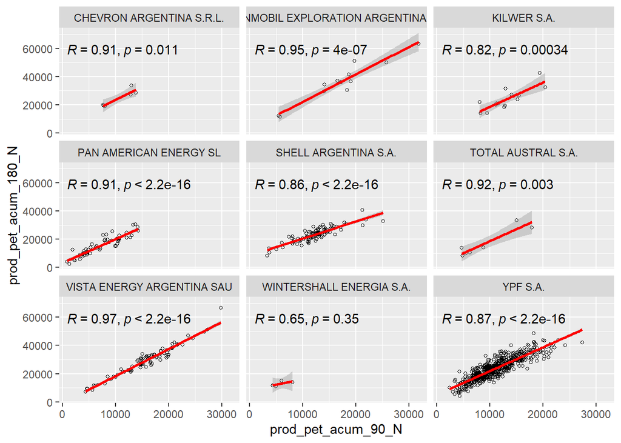

```r
f_1 <- df_frac_prod_tran %>%
  group_by(last_empresa)%>%
  filter(n()>2)%>%
  ggplot(mapping=aes(x=prod_pet_acum_90_N, y=prod_pet_acum_180_N))+
  geom_point(shape=21, size=1)+
  geom_smooth(method = "lm",formula = y ~ poly(x, 1),se=TRUE,level=0.95,color='red')+
  ggpubr::stat_cor()+
  facet_wrap(~last_empresa)

f_1
```

### Estimación productividad 180 días

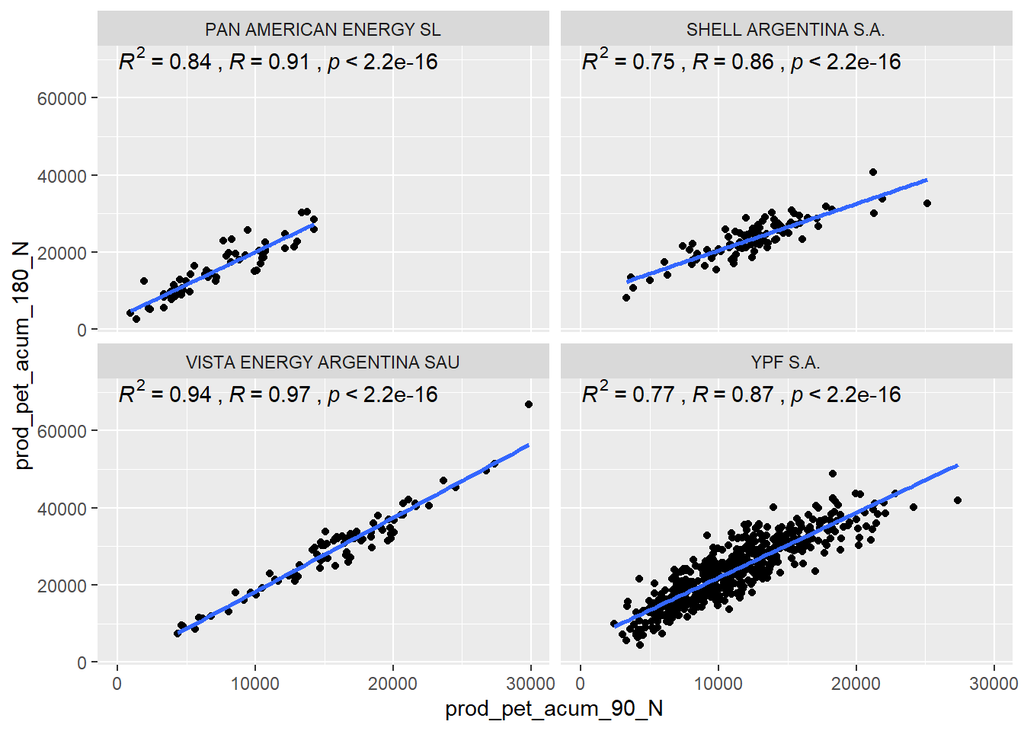

```r
f_2 <- df_frac_prod_tran %>%
  group_by(last_empresa)%>%
  filter(n()>50)%>%
  ungroup()%>%
  ggplot(mapping=aes(x=prod_pet_acum_90_N, y= prod_pet_acum_180_N))+
  geom_point()+
  geom_smooth(method=lm,se=FALSE)+
  facet_wrap(~last_empresa)+
  theme(legend.position = 'none')+
    ggpubr::stat_cor(aes(label = paste(..rr.label..,..r.label.., ..p.label.., sep = "~`,`~")),label.x = 3,label.y = 70000)


f_2
```

### Estimación productividad 360 días

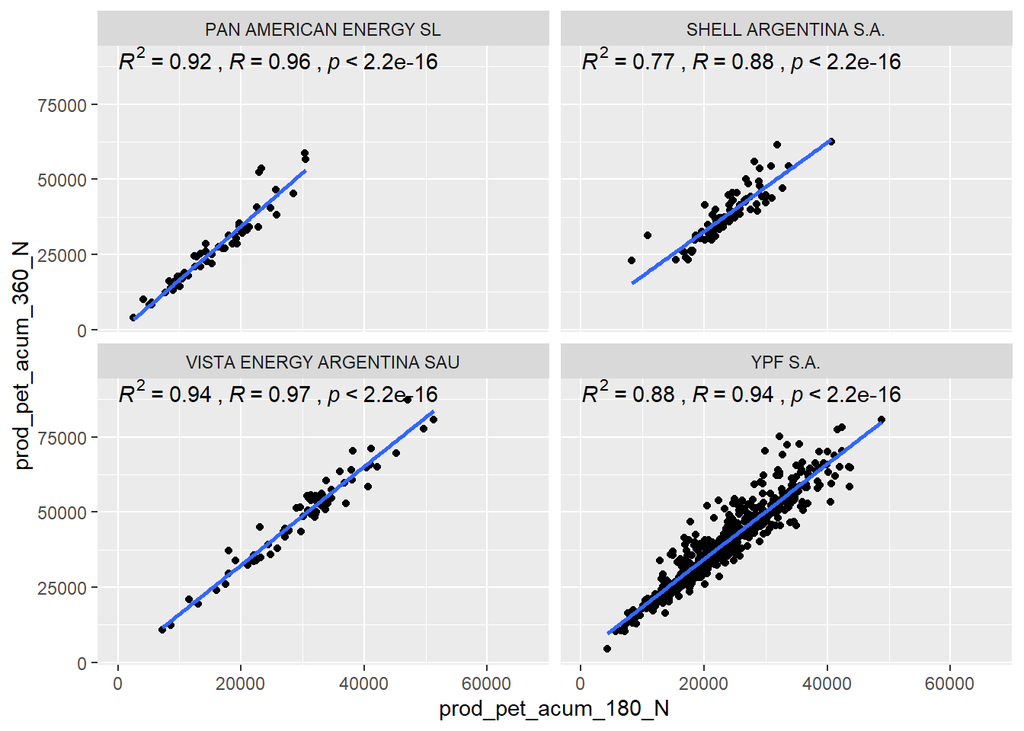

```r
f_3 <- df_frac_prod_tran %>%
  group_by(last_empresa)%>%
  filter(n()>50)%>%
  ungroup()%>%
  ggplot(mapping=aes(x=prod_pet_acum_180_N, y= prod_pet_acum_360_N))+
  geom_point()+
  geom_smooth(method=lm,se=FALSE)+
  facet_wrap(~last_empresa)+
  theme(legend.position = 'none')+
    ggpubr::stat_cor(aes(label = paste(..rr.label..,..r.label.., ..p.label.., sep = "~`,`~")),label.x = 3,label.y = 90000)


f_3
```

### Estimación productividad 720 días

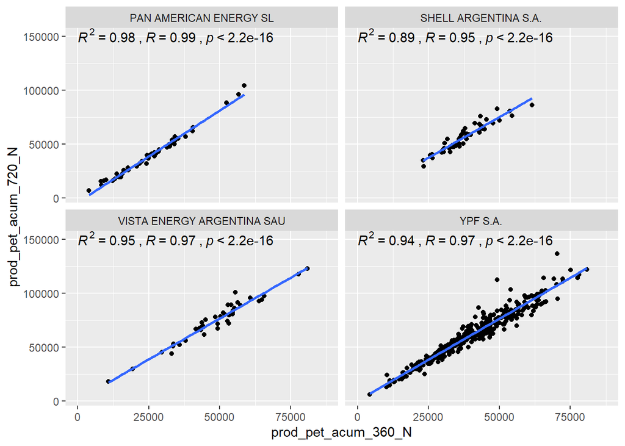

```r
f_4 <- df_frac_prod_tran %>%
  group_by(last_empresa)%>%
  filter(n()>50)%>%
  ungroup()%>%
  ggplot(mapping=aes(x=prod_pet_acum_360_N, y= prod_pet_acum_720_N))+
  geom_point()+
  geom_smooth(method=lm,se=FALSE)+
  facet_wrap(~last_empresa)+
  theme(legend.position = 'none')+
    ggpubr::stat_cor(aes(label = paste(..rr.label..,..r.label.., ..p.label.., sep = "~`,`~")),label.x = 3,label.y = 150000)


f_4
```

**Concluimos que hay elevada correlatividad de los acumulados reales con su acumulado superior. Los coeficientes de determinación son altos también, entonces por medio de la ecuación de la recta resultante de la regresión lineal. podremos estimar cualquier acumulado con el acumulado real inferior**

## Maxima productividad

```r
 df_frac_prod_tran <-
  mutate(df_frac_prod_tran, rango_espaciamiento=cut_width(espaciamiento, width=10, boundary=0),.after = espaciamiento)%>%
  mutate(across(where(is.numeric), round, 0))

tab_1 <- df_frac_prod_tran%>%
  group_by(rango_espaciamiento)%>%
  summarise(prod_pet_mean_90_N=median(prod_pet_acum_90_N[which(!is.na(prod_pet_acum_90_N))]),prod_pet_mean_180_N=median(prod_pet_acum_180_N[which(!is.na(prod_pet_acum_180_N))]),prod_pet_mean_360_N=median(prod_pet_acum_360_N[which(!is.na(prod_pet_acum_360_N))]),prod_pet_mean_720_N=median(prod_pet_acum_720_N[which(!is.na(prod_pet_acum_720_N))]))

rmarkdown::paged_table(tab_1)
```

| rango_espaciamiento | prod_pet_mean_90_N | prod_pet_mean_180_N | prod_pet_mean_360_N | prod_pet_mean_720_N |
| --- | --- | --- | --- | --- |
| [20,30] | 4275.5 | 10784.0 | 16534.0 | 22789.5 |
| (30,40] | 11890.0 | 27400.0 | 38993.0 | 51607.0 |
| (40,50] | 16632.0 | 32079.0 | 52134.0 | 79592.5 |
| (50,60] | 13251.0 | 27699.0 | 49272.0 | 72061.0 |
| (60,70] | 11593.5 | 26086.5 | 46379.0 | 75850.0 |
| (70,80] | 10708.5 | 21850.0 | 35939.0 | 54701.5 |
| (80,90] | 8492.5 | 18090.0 | 32982.5 | 51493.0 |
| (90,100] | 9005.5 | 17420.0 | 26937.0 | 42783.0 |
| (100,110] | 7593.0 | 17454.0 | 26068.0 | 42199.0 |
| (110,120] | 10719.0 | 20144.0 | 32361.0 | 47980.0 |

[output cut: 2 more lines]

Grafiquemos en boxplot lo resultados que encontramos en la tab_1

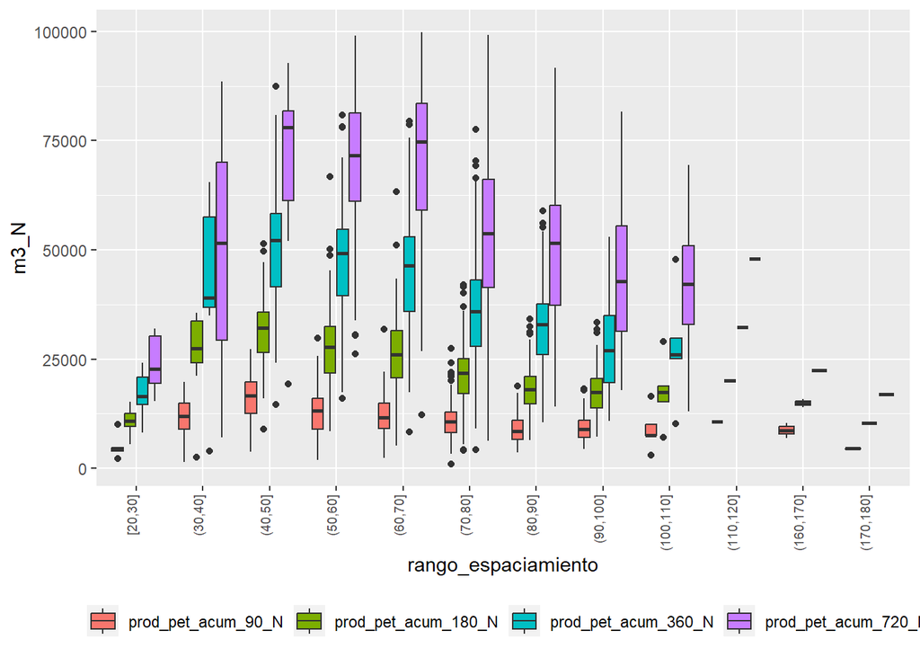

```r
f_5 <- df_frac_prod_tran %>%
  pivot_longer(cols=c('prod_pet_acum_90_N','prod_pet_acum_180_N','prod_pet_acum_360_N','prod_pet_acum_720_N'),names_to='prod_pet_acum_N',
               values_to='m3_N')%>%
  ggplot(mapping=aes(x=rango_espaciamiento, y= m3_N,fill=factor(prod_pet_acum_N,levels=c('prod_pet_acum_90_N','prod_pet_acum_180_N','prod_pet_acum_360_N','prod_pet_acum_720_N'))))+
  theme(axis.text.x = element_text(size=7,angle=90, hjust=1,vjust=0))+
  geom_boxplot()+
  theme(legend.position="bottom",legend.title=element_blank())+
  ylim(NA, 100000)
f_5
```

**De acuerdo a la fig_5 podemos recomendar que la productividad esta realacionada con el espaciamiento entre fracturas, siendo el rango de 40 mt a 50 mt el mas adecuado para futuros pozos**